# Update

2019-2-20

# Step 1:

I was confused about the dimensions of the following equation. I just wanted to add the subscript i in the equation and specify the euqation for each subject.

To calculate the max purity function, first, fit the linear mixed model for the outcome $\mathbf{y_i}$ and time $\mathbf{X_i}$, with baseline covariates $\mathbf{x_i}$:
$$\mathbf{y_i} = \mathbf{X_i}(\mathbf{\beta} +\mathbf{b_i} +\mathbf{\Gamma}(\mathbf{\alpha}'\mathbf{x_i})) + \mathbf{\epsilon_i}.$$
where,

- $\mathbf{y_i}$ is the vector of outcomes for the $i$th subject, i.e., the dimension of $\mathbf{y_i}$ is ($n_i$, 1). $n_i$ is the number of observations for the $i$th subject.
- $\mathbf{X_i}$ is the covariate matrix for $i$th subject. The dimension is ($n_i$, p). Here in our example, it is ($n_i$,3).
- $\mathbf{\beta}$ is the coeffcient vector for the fixed effects of $\mathbf{X_i}$. Dimension is (p,1).
- $\mathbf{x_i}$ is the vector of baseline covariates for the subject. The dimension is (q, 1).
- $\mathbf{b_i}$ is the vector of random effects. Dimension is (p,1).
- $\mathbf{\Gamma}$ is the vector of fixed effects of the baseline covariates. Dimension is (p,1).
- $w_i=\mathbf{\alpha}'\mathbf{x_i}$ is the combination of the input baseline covariates. $w_i$ is a scalar.

We can define the covariate matrix of $\mathbf{X_i}$ as $\mathbf{z_i}$. The $\mathbf{z_i}$ contains both fixed effects and random effects.
$$\mathbf{z_i} = \mathbf{\beta} + \mathbf{b_i} + \mathbf{\Gamma} w_i$$
We can also write the above equation in the matrix version:
$$Y_i = \left[\begin{array}
{rrr}
1 & t_1 & t_1^2 \\
1 & t_2 & t_2^2 \\
... & ... & ... \\
1 & t_{n_{i}} & t_{n_{i}}^2
\end{array}\right]
\left[\begin{pmatrix}
\beta_0 \\
\beta_1 \\
\beta_2
\end{pmatrix} +
\begin{pmatrix}
b_{i0} \\
b_{i1} \\
b_{i2}
\end{pmatrix} +
\begin{pmatrix}
\gamma_0 \\
\gamma_1 \\
\gamma_2
\end{pmatrix} w_i \right] + \mathbf{\epsilon_i}$$
For different subjects, they have the same $\mathbf{\beta}$ vector and the same $\mathbf{\Gamma}$ vector. Their random effect vector $\mathbf{b_i}$ are different.

Sorry I am still feel a little confused here. How could we combine the $Y_i$, $X_i$ and the matrix of coefficients of each subject together to get an overall equation?

### Estimate the $\mathbf{\beta}$ ,$\mathbf{\Gamma}$, $\mathbf{b_i}$ in R

Let the ‘newcov’ = ‘BaselineCGI’

```r
dat$newcov = dat$BaselineCGI
d0 = dat[dat$trt == 0 ,]
d1 = dat[dat$trt == 1 ,]
fit_d0 = lmer(y ~ t1 + I(t1^2) + newcov + newcov * t1 +
                newcov * I(t1^2) + (t1+I(t1^2)|subj),
              data = d0, REML = FALSE)
fit_d1 = lmer(y ~ t1 + I(t1^2) + newcov + newcov * t1 +
                newcov * I(t1^2) + (t1+I(t1^2)|subj),
              data = d1, REML = FALSE)
```

The estimated beta and gamma is

```r
beta_d0 = as.matrix(fixef(fit_d0)[1:3])
gamma_d0 = as.matrix(fixef(fit_d0)[4:6])
beta_d1 = as.matrix(fixef(fit_d1)[1:3])
gamma_d1 = as.matrix(fixef(fit_d1)[4:6])
```

```r
beta_d0
```

```
##                   [,1]
## (Intercept) 14.0172657
## t1          -5.0133105
## I(t1^2)      0.7171924
```

```r
gamma_d0
```

```
##                       [,1]
## newcov          2.04212314
## t1:newcov       0.17005552
## I(t1^2):newcov -0.04868318
```

```r
beta_d1
```

```
##                  [,1]
## (Intercept) 13.455594
## t1          -3.400881
## I(t1^2)      0.484097
```

```r
gamma_d1
```

```
##                       [,1]
## newcov          2.28686752
## t1:newcov      -0.19895847
## I(t1^2):newcov -0.02576792
```

# Step 2

Then we need to estimate the distribution of $\mathbf{z_i}$ for drug group and placebo, separately.
$$\begin{aligned}
f(z_i) &= \int_{w_{i}} f(z_i,w_i) dw_i \\
& = \int_{w_i} f(z_i|w_i) g(w_i) dw_i
\end{aligned}$$
where,

- the conditional distribution $f(z_i|w_i) \sim MVN( \mathbf{\beta} + \mathbf{\Gamma} w_i, \mathbf{D_i})$
- $g(w_i)$ is the distribution of the covariates combination. For example, if the covariates combination only contains “sex”, which is binary, then the intergal becomes summation.
- $\mathbf{D_i}$ is the covariates matrix of random effects $\mathbf{b_i}$.

We could then fit the $f(\cdot)$ for drug group and placebo group separately, i.e. $f_1(z)$ and $f_2(z)$.

# Step 3: Define the purity

The purity should be a function of $w_i$. First calculate the integral of $z_i$. Then,
$$P_{w_i} = \int_{z_i} \frac{[f_1(z_i|w_i) - f_2(z_i|w_i)]^2}{[f_1(z_i|w_i) + f_2(z_i|w_i)]^2} (f_1(z_i|w_i) + f_2(z_i|w_i)) dz_i = \int_{z_i} \frac{[f_1(z_i|w_i) - f_2(z_i|w_i)]^2}{f_1(z_i|w_i) + f_2(z_i|w_i)} dz_i$$

## Purity calculation in R

Since the difference of age and baseline CGI are not very significant, I added two new covariates, which were generated by myself.

#### add new covariates

```r
d0 = dat[dat$trt == 0 ,]
# new covariate 1, sampled from 1:20
# new covariate 2, sampled from -20:-1
cov01 = sample(1:20, length(unique(d0$subj)), replace =TRUE)
cov02 = sample(-20:(-1), length(unique(d0$subj)), replace =TRUE)
newcov0 = data.frame(subj = unique(d0$subj), newcov1 = cov01, newcov2 = cov02)
d0 = merge(d0,newcov0, by = 'subj')
head(d0)
```

```
##   subj trt  y age BaselineCGI t1 responder newcov1 newcov2
## 1 2497   0 25  29           4  0         0       9      -6
## 2 2497   0 18  29           4  1         0       9      -6
## 3 2497   0 11  29           4  2         0       9      -6
## 4 2497   0  9  29           4  3         0       9      -6
## 5 2497   0 19  29           4  4         0       9      -6
## 6 2497   0 15  29           4  5         0       9      -6
```

```r
d1 = dat[dat$trt == 1 ,]
cov01 = sample(-20:(-1), length(unique(d1$subj)), replace =TRUE)
cov02 = sample(1:20, length(unique(d1$subj)), replace =TRUE)
newcov1 = data.frame(subj = unique(d1$subj), newcov1 = cov01, newcov2 = cov02)
d1 = merge(d1,newcov1, by = 'subj')
dat = rbind(d0,d1)
head(d1)
```

```
##   subj trt  y age BaselineCGI t1 responder newcov1 newcov2
## 1 2500   1 24  29           4  0         0     -16       6
## 2 2500   1 22  29           4  1         0     -16       6
## 3 2500   1 19  29           4  2         0     -16       6
## 4 2500   1 25  29           4  3         0     -16       6
## 5 2509   1 24  31           4  0         1      -4       8
## 6 2509   1 10  31           4  1         1      -4       8
```

#### fit lme models

```r
dat$newcov = dat$newcov1 + dat$newcov2
d0 = dat[dat$trt == 0 ,]
d1 = dat[dat$trt == 1 ,]
fit_d0 = lmer(y ~ t1 + I(t1^2) + newcov + newcov * t1 +
                newcov * I(t1^2) + (t1+I(t1^2)|subj),
                data = d0, REML = FALSE)
fit_d1 = lmer(y ~ t1 + I(t1^2) + newcov + newcov * t1 +
                newcov * I(t1^2) + (t1+I(t1^2)|subj),
                data = d1, REML = FALSE)
summary(fit_d0)
```

```
## Linear mixed model fit by maximum likelihood  ['lmerMod']
## Formula: y ~ t1 + I(t1^2) + newcov + newcov * t1 + newcov * I(t1^2) +
##     (t1 + I(t1^2) | subj)
##    Data: d0
##
##      AIC      BIC   logLik deviance df.resid
##   5972.0   6035.5  -2973.0   5946.0      965
##
## Scaled residuals:
##     Min      1Q  Median      3Q     Max
## -4.2543 -0.5928 -0.0191  0.5395  2.9287
##
## Random effects:
##  Groups   Name        Variance Std.Dev. Corr
##  subj     (Intercept)  2.2965  1.5154
##           t1           4.9707  2.2295    0.92
##           I(t1^2)      0.1148  0.3388   -0.99 -0.87
##  Residual             16.1510  4.0188
## Number of obs: 978, groups:  subj, 162
##
## Fixed effects:
##                 Estimate Std. Error t value
## (Intercept)    23.065063   0.303475  76.003
## t1             -4.259948   0.290878 -14.645
## I(t1^2)         0.502793   0.048769  10.310
## newcov          0.039980   0.039826   1.004
## t1:newcov      -0.063245   0.038063  -1.662
## I(t1^2):newcov  0.010462   0.006368   1.643
##
## Correlation of Fixed Effects:
##             (Intr) t1     I(t1^2) newcov t1:nwc
## t1          -0.346
## I(t1^2)      0.238 -0.915
## newcov      -0.025  0.005 -0.001
## t1:newcov    0.005 -0.019  0.012  -0.345
## I(t1^2):nwc -0.001  0.012 -0.008   0.236 -0.914
```

```r
summary(fit_d1)
```

```
## Linear mixed model fit by maximum likelihood  ['lmerMod']
## Formula: y ~ t1 + I(t1^2) + newcov + newcov * t1 + newcov * I(t1^2) +
##     (t1 + I(t1^2) | subj)
##    Data: d1
##
##      AIC      BIC   logLik deviance df.resid
##   7283.1   7349.6  -3628.6   7257.1     1218
##
## Scaled residuals:
##     Min      1Q  Median      3Q     Max
## -3.2439 -0.5483 -0.0432  0.5169  3.3949
##
## Random effects:
##  Groups   Name        Variance Std.Dev. Corr
##  subj     (Intercept)  8.1906  2.8619
##           t1           7.7743  2.7882    0.04
##           I(t1^2)      0.1602  0.4002   -0.19 -0.93
##  Residual             11.7479  3.4275
## Number of obs: 1231, groups:  subj, 196
##
## Fixed effects:
##                  Estimate Std. Error t value
## (Intercept)    23.6885876  0.2974696  79.634
## t1             -4.3115606  0.2659754 -16.210
## I(t1^2)         0.3714999  0.0413677   8.980
## newcov         -0.0006681  0.0371885  -0.018
## t1:newcov      -0.0403921  0.0332721  -1.214
## I(t1^2):newcov  0.0047811  0.0051969   0.920
##
## Correlation of Fixed Effects:
##             (Intr) t1     I(t1^2) newcov t1:nwc
## t1          -0.349
## I(t1^2)      0.223 -0.934
## newcov       0.056 -0.017  0.009
## t1:newcov   -0.017  0.050 -0.042  -0.350
## I(t1^2):nwc  0.009 -0.042  0.036   0.224 -0.933
```

#### calculate the integral

```r
beta0 = as.matrix(fixef(fit_d0)[1:3])
gamma0 = as.matrix(fixef(fit_d0)[4:6])

beta1 = as.matrix(fixef(fit_d1)[1:3])
gamma1 = as.matrix(fixef(fit_d1)[4:6])

w = 1 # let w = 1 first
m0 = beta0 + gamma0 * w; m0 = m0[2:3] # ignore the intercept
m1 = beta1 + gamma1 * w; m1 = m1[2:3]

D0 = as.matrix(VarCorr(fit_d0)$subj)[2:3, 2:3]
D1 = as.matrix(VarCorr(fit_d1)$subj)[2:3, 2:3]

mu0 = matrix(m0, nrow=2)
sigma0 = D0
mu1 = matrix(m1, nrow=2)
sigma1 = D1

quadratic0 = function(a,b) {
    X = matrix(c(a,b),nrow=2)
    Q = (-1/2)*t(X-mu0)%*%solve(sigma0)%*%(X-mu0)
}
quadratic1 = function(a,b) {
    X = matrix(c(a,b),nrow=2)
    Q = (-1/2)*t(X-mu1)%*%solve(sigma1)%*%(X-mu1)
}

PDF = function(x) {
  f0 = (1/(2*pi))*(1/sqrt(det(sigma0)))*exp(quadratic0(x[1],x[2]))
  f1 = (1/(2*pi))*(1/sqrt(det(sigma1)))*exp(quadratic1(x[1],x[2]))
  if((f0 + f1)!=0){
      res = (f0 - f1)^2 / (f0 + f1)
    }else{res = 0}
  return(res)
}
```

#### calculate the purity

Input different $w_i$ in the dataset. Each $w_i$ can return a value of the above integral. Sum all the values for all the $w_i$ to get the purity.

```r
library(cubature)
# get unique w value for each subject
W = data.frame(subj = dat$subj, newcov = dat$newcov)
W = unique(W)

P = c() # save the purity value in P
for(i in W$newcov){
    w = i
    m0 = beta0 + gamma0 * w; m0 = m0[2:3]
    m1 = beta1 + gamma1 * w; m1 = m1[2:3]
    D0 = as.matrix(VarCorr(fit_d0)$subj)[2:3, 2:3]
    D1 = as.matrix(VarCorr(fit_d1)$subj)[2:3, 2:3]

    mu0 =  matrix(m0, nrow=2)
    sigma0 = D0
    mu1 = matrix(m1, nrow=2)
    sigma1 = D1

    P = c(P,adaptIntegrate(PDF,
                           lowerLimit= c(-1,-1),
                           upperLimit=c(1,1))$integral)
  }
mean(P) #  0.1076019
```

```
## [1] 0.03092596
```

```r
sum(P) # 38.52146
```

```
## [1] 11.07149
```

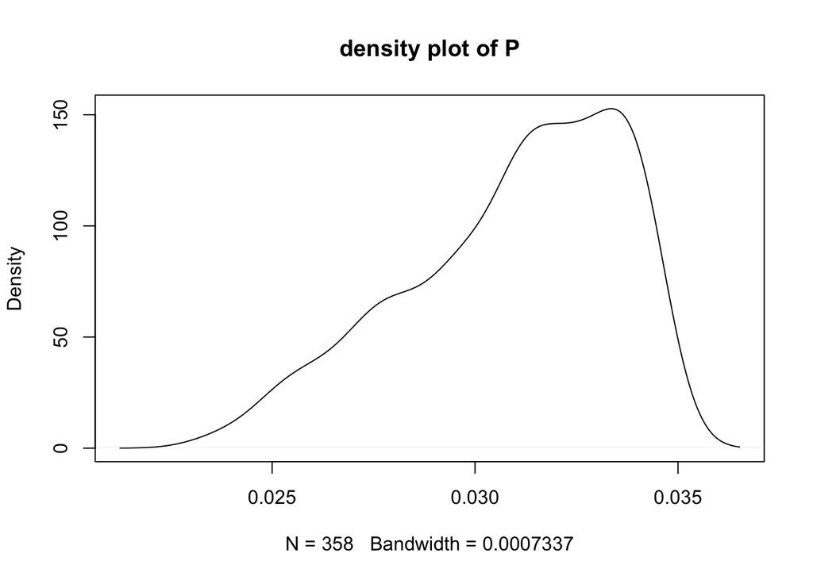

```r
plot(density(P) , main = 'density plot of P')
```

#### wrap up the above into a function and change the value of w

```r
purity = function(a1,a2){
  dat$newcov = a1 * dat$newcov1 + a2 * dat$newcov2
  d0 = dat[dat$trt == 0, ]
  d1 = dat[dat$trt == 1, ]
  fit_d0 = lmer(y ~ t1 + I(t1^2) + newcov + newcov * t1 +
                newcov * I(t1^2) + (t1+I(t1^2)|subj),
                data = d0, REML = FALSE)
  fit_d1 = lmer(y ~ t1 + I(t1^2) + newcov + newcov * t1 +
                newcov * I(t1^2) + (t1+I(t1^2)|subj),
                data = d1, REML = FALSE)

  beta0 = as.matrix(fixef(fit_d0)[1:3])
  gamma0 = as.matrix(fixef(fit_d0)[4:6])

  beta1 = as.matrix(fixef(fit_d1)[1:3])
  gamma1 = as.matrix(fixef(fit_d1)[4:6])

  W = data.frame(subj = dat$subj, newcov = dat$newcov)
  W = unique(W)

  P = c() # save the purity value in P
  for(i in W$newcov){
    w = i
    m0 = beta0 + gamma0 * w; m0 = m0[2:3]
    m1 = beta1 + gamma1 * w; m1 = m1[2:3]
    D0 = as.matrix(VarCorr(fit_d0)$subj)[2:3, 2:3]
    D1 = as.matrix(VarCorr(fit_d1)$subj)[2:3, 2:3]

    mu0 =  matrix(m0, nrow=2)
    sigma0 = D0
    mu1 = matrix(m1, nrow=2)
    sigma1 = D1
    quadratic0 = function(a,b) {
        X = matrix(c(a,b),nrow=2)
        Q = (-1/2)*t(X-mu0)%*%solve(sigma0)%*%(X-mu0)
    }
    quadratic1 = function(a,b) {
        X = matrix(c(a,b),nrow=2)
        Q = (-1/2)*t(X-mu1)%*%solve(sigma1)%*%(X-mu1)
    }

    PDF = function(x) {
        f0 = (1/(2*pi))*(1/sqrt(det(sigma0)))*exp(quadratic0(x[1],x[2]))
        f1 = (1/(2*pi))*(1/sqrt(det(sigma1)))*exp(quadratic1(x[1],x[2]))
        if((f0 + f1)!=0){
           res = (f0 - f1)^2 / (f0 + f1)
        }else{res = 0}
           return(res)
        }
    P = c(P,adaptIntegrate(PDF,
                           lowerLimit= c(-1,-1),
                           upperLimit=c(1,1))$integral)
    }
   return(list(w = W$newcov, P = P))
}
```

Vary the a1 and a2 to find the max value of purity.

Before applying the Newton Raphson method, maybe we can vary some a1 and a2 value to see the trend of this function.

```r
A1 = c(); A2 = c(); pp = c()
for(a1 in seq(-3,3,1)){
for(a2 in seq(-3,3,1)){
if(a1^2 + a2^2 !=0){
A1 = c(A1, a1)
A2 = c(A2, a2)
pp = c(pp,sum(purity(a1,a2)$P))
}
}
}

data.frame(A1,A2,pp)
```

```
##    A1 A2        pp
## 1  -3 -3 11.072054
## 2  -3 -2  9.470951
## 3  -3 -1 11.203608
## 4  -3  0 16.712585
## 5  -3  1 18.843648
## 6  -3  2 16.423506
## 7  -3  3 13.292842
## 8  -2 -3 13.291490
## 9  -2 -2 11.071495
## 10 -2 -1  9.667950
## 11 -2  0 16.712530
## 12 -2  1 17.954829
## 13 -2  2 13.292882
## 14 -2  3 10.628425
```

[output cut: 34 more lines]